# Exercise-09

Jessica V

2024-03-31

```r
library(tidyverse)
library(skimr)
```

#Step 1 # #Here I load in the data “Street_et_al_2017.csv” as a tbble named d

```r
f <- "https://raw.githubusercontent.com/difiore/ada-2024-datasets/main/Street_et_al_2017.csv"

d <- read_csv(f, col_names = TRUE)
```

# # Here I do a quick exploratory data analysis where I generate the five-number summary (median, minimum and maximum and 1st and 3rd quartile values), plus mean and standard deviation, for each quantitative variable.

```r
skim(d)
```

Data summary

| Name | d |
| --- | --- |
| Number of rows | 301 |
| Number of columns | 13 |
| _______________________ |  |
| Column type frequency: |  |
| character | 2 |
| numeric | 11 |
| ________________________ |  |
| Group variables | None |

**Variable type: character**

| skim_variable | n_missing | complete_rate | min | max | empty | n_unique | whitespace |
| --- | --- | --- | --- | --- | --- | --- | --- |
| Species | 0 | 1 | 10 | 41 | 0 | 301 | 0 |
| Taxonomic_group | 0 | 1 | 10 | 12 | 0 | 3 | 0 |

**Variable type: numeric**

| skim_variable | n_missing | complete_rate | mean | sd | p0 | p25 | p50 | p75 | p100 | hist |
| --- | --- | --- | --- | --- | --- | --- | --- | --- | --- | --- |
| Social_learning | 98 | 0.67 | 2.30 | 16.51 | 0.00 | 0.00 | 0.00 | 0.00 | 214.00 | ▇▁▁▁▁ |
| Research_effort | 115 | 0.62 | 38.76 | 80.59 | 1.00 | 6.00 | 16.00 | 37.75 | 755.00 | ▇▁▁▁▁ |
| ECV | 117 | 0.61 | 68.49 | 82.84 | 1.63 | 11.82 | 58.55 | 86.20 | 491.27 | ▇▁▁▁▁ |
| Group_size | 114 | 0.62 | 13.26 | 15.20 | 1.00 | 3.12 | 7.50 | 18.23 | 91.20 | ▇▂▁▁▁ |
| Gestation | 161 | 0.47 | 164.50 | 38.00 | 59.99 | 138.35 | 166.03 | 183.26 | 274.78 | ▁▅▇▃▁ |
| Weaning | 185 | 0.39 | 311.09 | 253.08 | 40.00 | 121.66 | 234.16 | 388.78 | 1260.81 | ▇▃▁▁▁ |
| Longevity | 181 | 0.40 | 331.97 | 165.67 | 103.00 | 216.00 | 301.20 | 393.30 | 1470.00 | ▇▂▁▁▁ |
| Sex_maturity | 194 | 0.36 | 1480.23 | 999.23 | 283.18 | 701.52 | 1427.17 | 1894.11 | 5582.93 | ▇▆▂▁▁ |
| Body_mass | 63 | 0.79 | 6795.18 | 14229.83 | 31.23 | 739.44 | 3553.50 | 7465.00 | 130000.00 | ▇▁▁▁▁ |
| Maternal_investment | 197 | 0.35 | 478.64 | 292.07 | 99.99 | 255.88 | 401.35 | 592.22 | 1492.30 | ▇▅▂▁▁ |
| Repro_lifespan | 206 | 0.32 | 9064.97 | 4601.57 | 2512.16 | 6126.22 | 8325.89 | 10716.60 | 39129.57 | ▇▃▁▁▁ |

#Step 2 # # Here I plot brain size (ECV) as a function of social group size (Group_size), longevity (Longevity), juvenile period length (Weaning), and reproductive lifespan (Repro_lifespan).

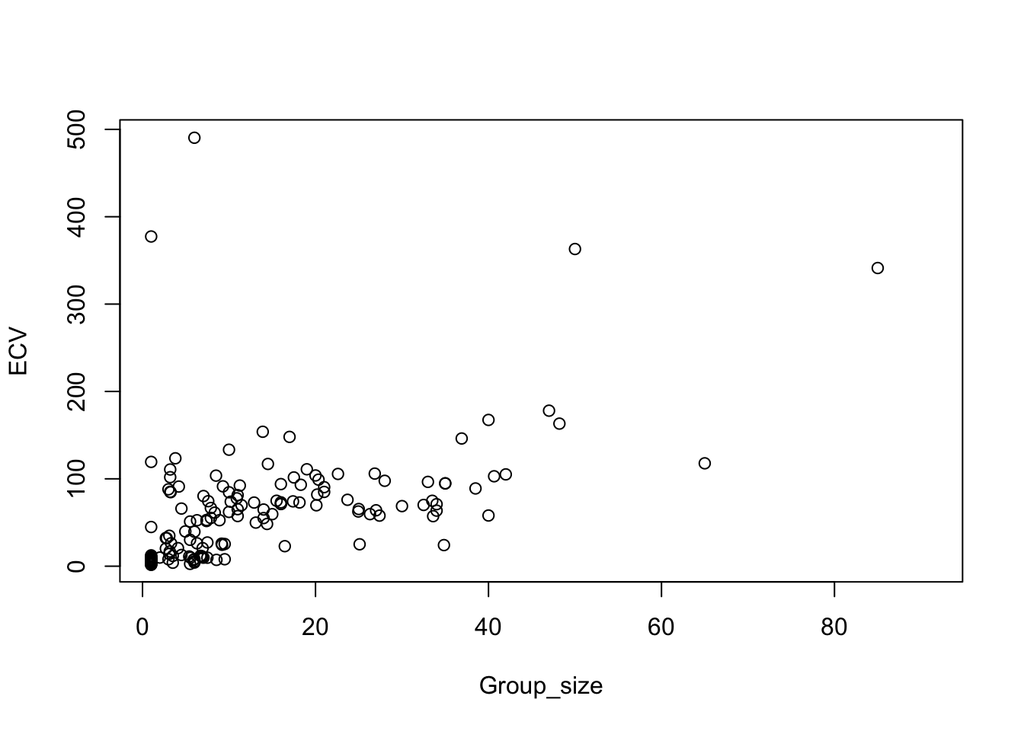

```r
library(ggplot2)

plot(data = d, ECV ~ Group_size)
```

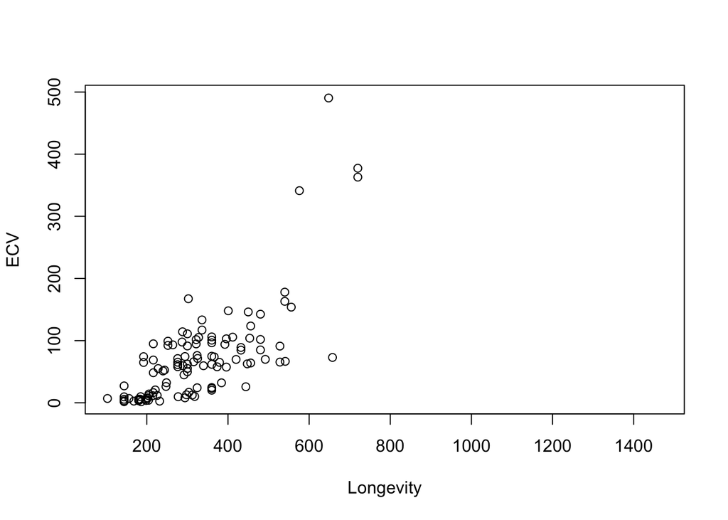

```r
plot(data = d, ECV ~ Longevity)
```

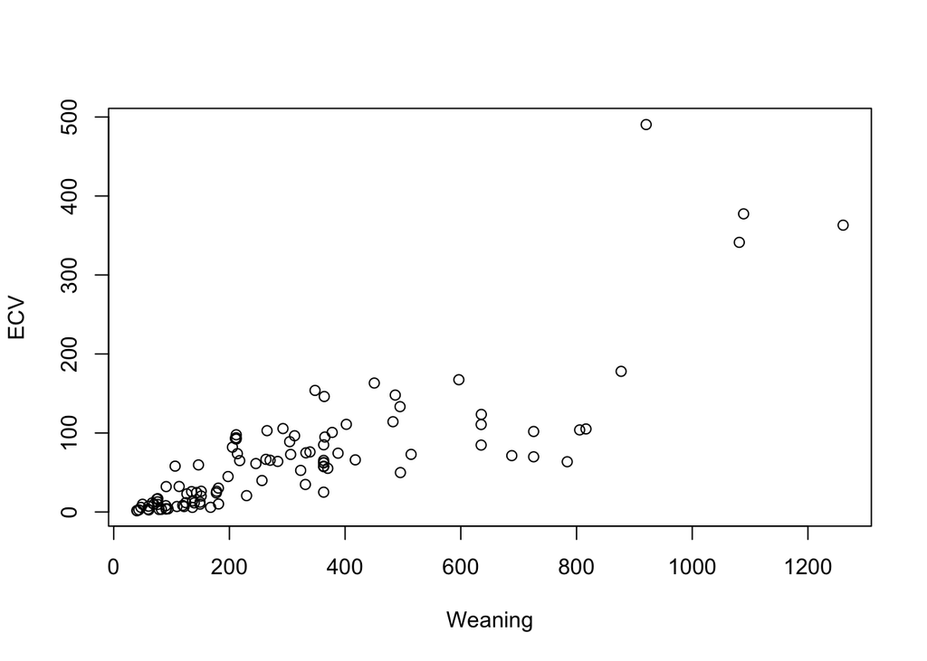

```r
plot(data = d, ECV ~ Weaning)
```

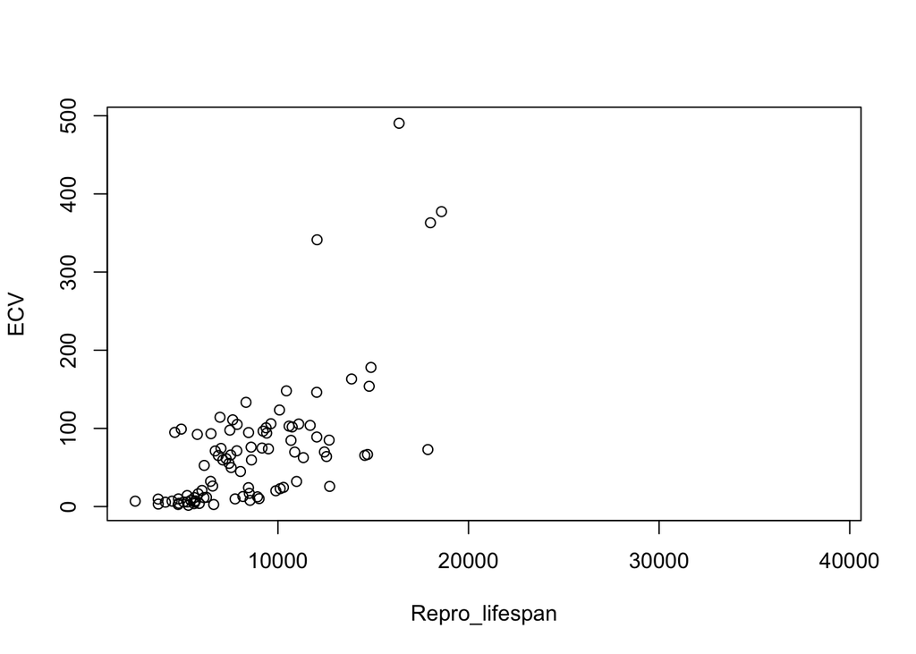

```r
plot(data = d, ECV ~ Repro_lifespan)
```

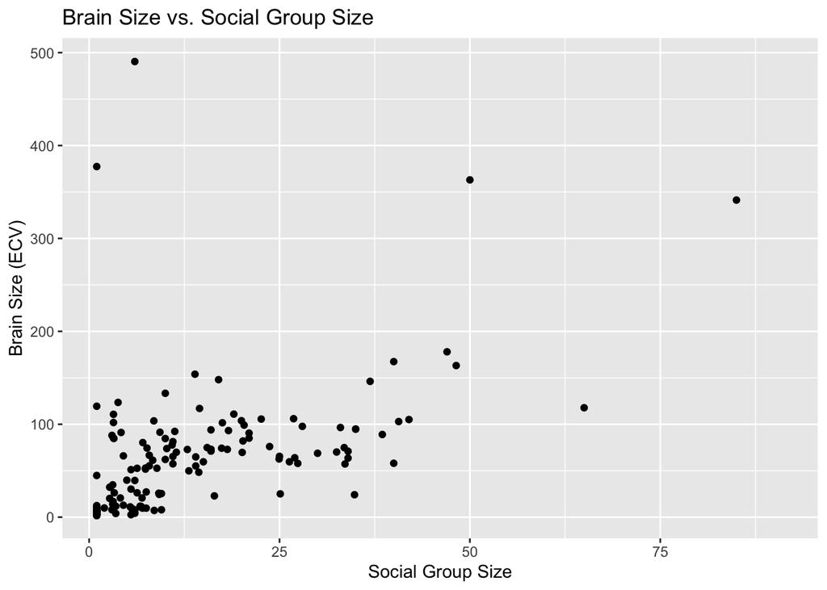

```r
ggplot(d, aes(x = Group_size, y = ECV)) +
  geom_point() +
  labs(x = "Social Group Size", y = "Brain Size (ECV)", title = "Brain Size vs. Social Group Size")
```

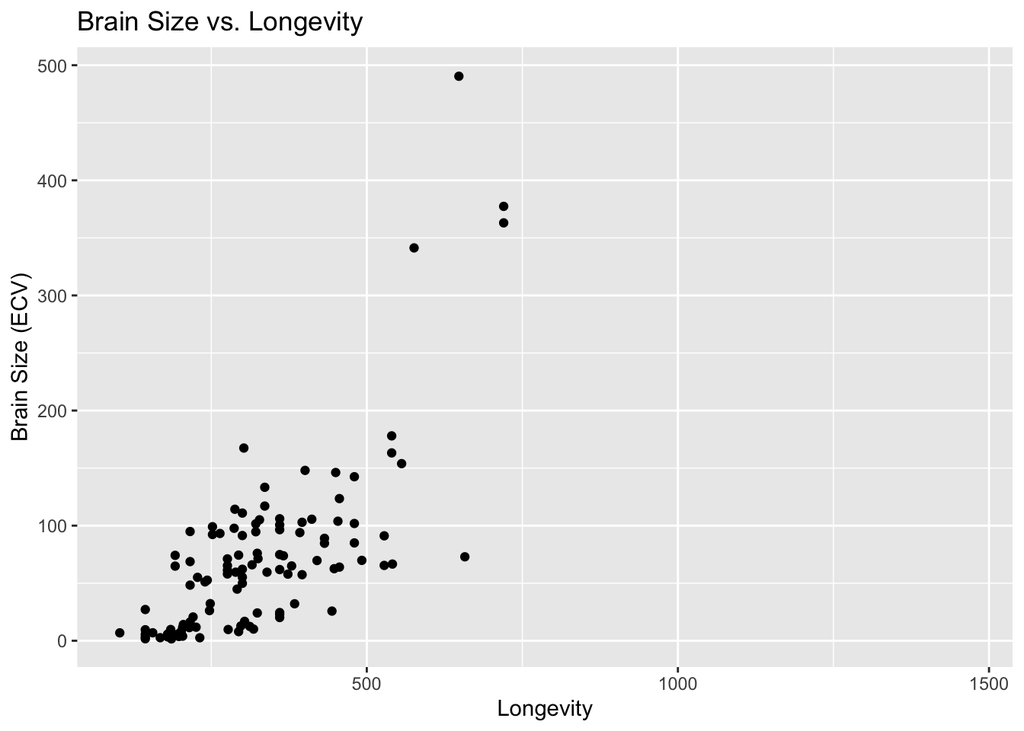

```r
ggplot(d, aes(x = Longevity, y = ECV)) +
  geom_point() +
  labs(x = "Longevity", y = "Brain Size (ECV)", title = "Brain Size vs. Longevity")
```

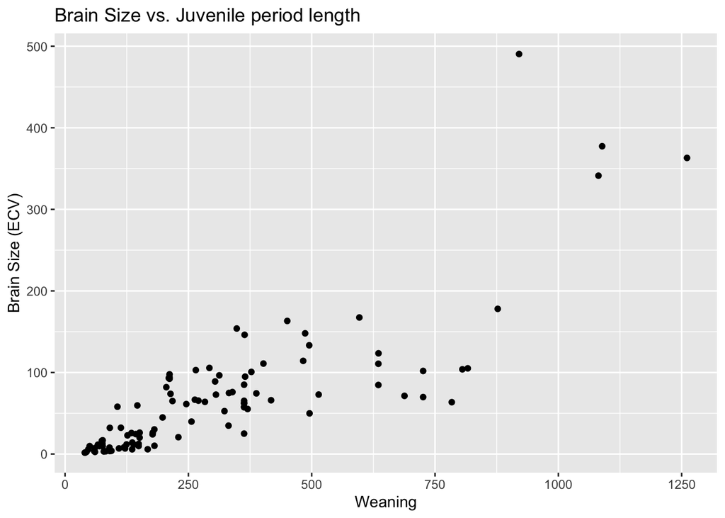

```r
ggplot(d, aes(x = Weaning, y = ECV)) +
  geom_point() +
  labs(x = "Weaning", y = "Brain Size (ECV)", title = "Brain Size vs. Juvenile period length ")
```

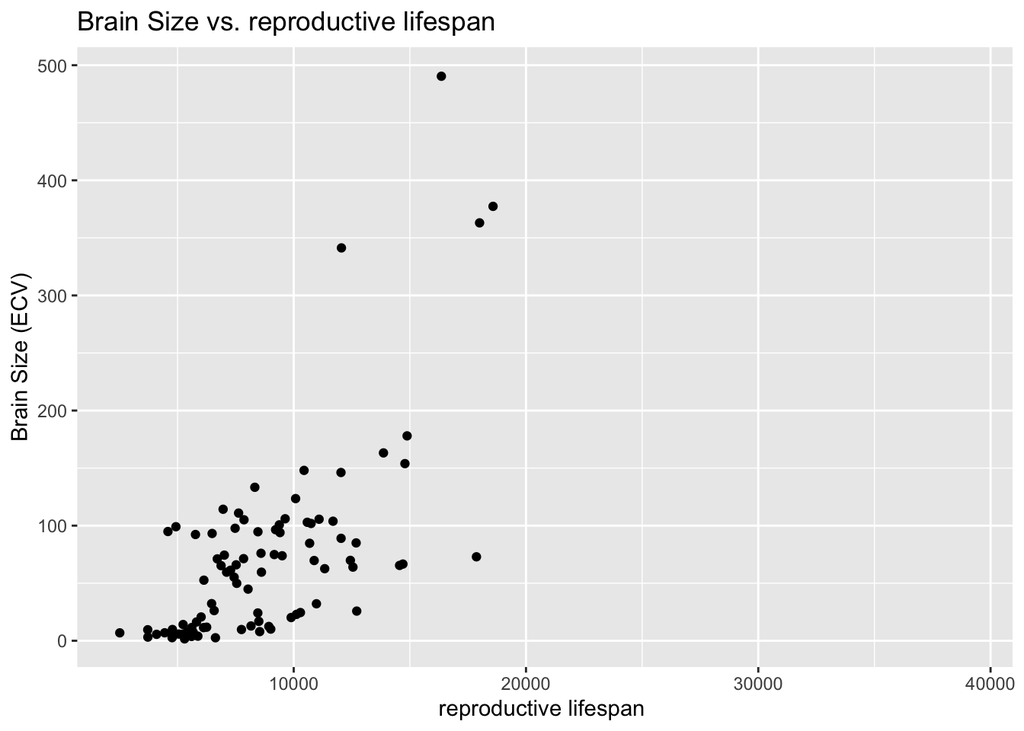

```r
ggplot(d, aes(x = Repro_lifespan, y = ECV)) +
  geom_point() +
  labs(x = "reproductive lifespan ", y = "Brain Size (ECV)", title = "Brain Size vs. reproductive lifespan")
```

Step 3 Here I derive by hand the ordinary least squares regression coefficients and for ECV as a function of social group size. HINT: You will need to remove rows from your dataset where one of these variables is missing.

```r
d_complete <- d[complete.cases(d$ECV, d$Group_size), ]

#Beta1
(beta1 <- cor(d_complete$Group_size, d_complete$ECV) * (sd(d_complete$ECV)/sd(d_complete$Group_size)))
```

```
## [1] 2.463071
```

```r
beta1
```

```
## [1] 2.463071
```

```r
#(beta1 <- cor(d_complete$ECV, d_complete$Group_size) * (sd(d_complete$Group_size)/sd(d_complete$ECV)))

#(beta1 <- cov(d_complete$ECV, d_complete$Group_size)/var(d_complete$ECV))

#(beta1 <- sum((d_complete$Group_size - mean(d_complete$Group_size)) * (d_complete$ECV - mean(d_complete$ECV)))/sum((d_complete$ECV - mean(d_complete$ECV))^2))

#Beta0
(beta0 <- mean(d_complete$ECV) - beta1 * mean(d_complete$Group_size))
```

```
## [1] 30.35652
```

```r
beta0
```

```
## [1] 30.35652
```

Step 4 Confirm that you get the same results using the lm() function. Yes!

```r
m <- lm(d_complete$ECV ~ d_complete$Group_size, data = d)
m
```

```
##
## Call:
## lm(formula = d_complete$ECV ~ d_complete$Group_size, data = d)
##
## Coefficients:
##           (Intercept)  d_complete$Group_size
##                30.357                  2.463
```

Step 5 Repeat the analysis above for three different major radiations of primates - “catarrhines”, “platyrrhines”, and “strepsirhines”) separately. These are stored in the variable Taxonomic_group. Do your regression coefficients differ among groups? How might you determine this?

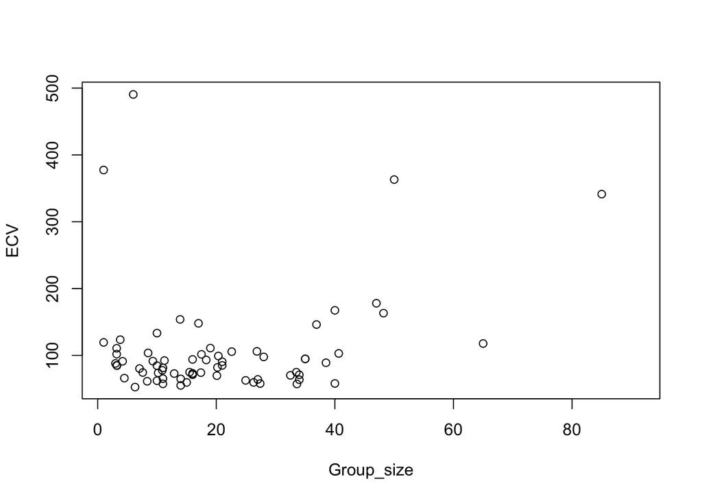

```r
#For catarrhines

Catarrhini <- d[d$Taxonomic_group == "Catarrhini", ]
plot(data = Catarrhini, ECV ~ Group_size)
```

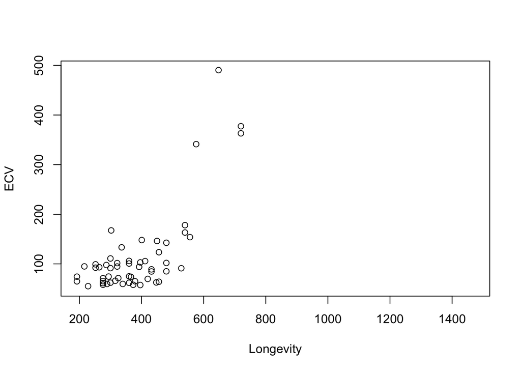

```r
plot(data = Catarrhini, ECV ~ Longevity)
```

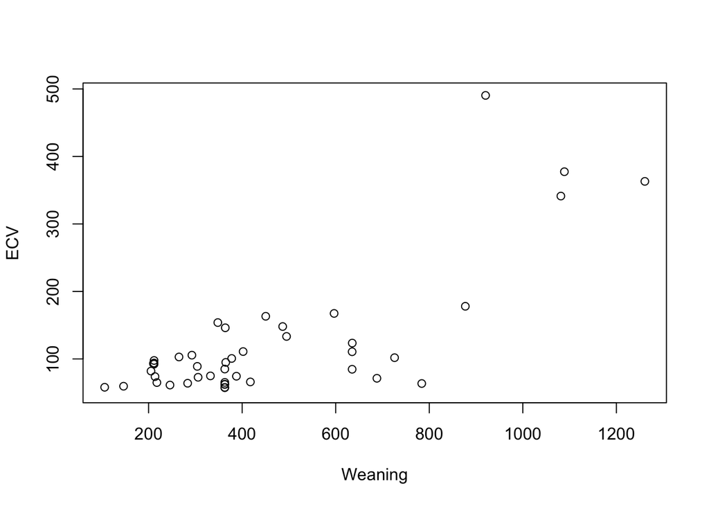

```r
plot(data = Catarrhini, ECV ~ Weaning)
```

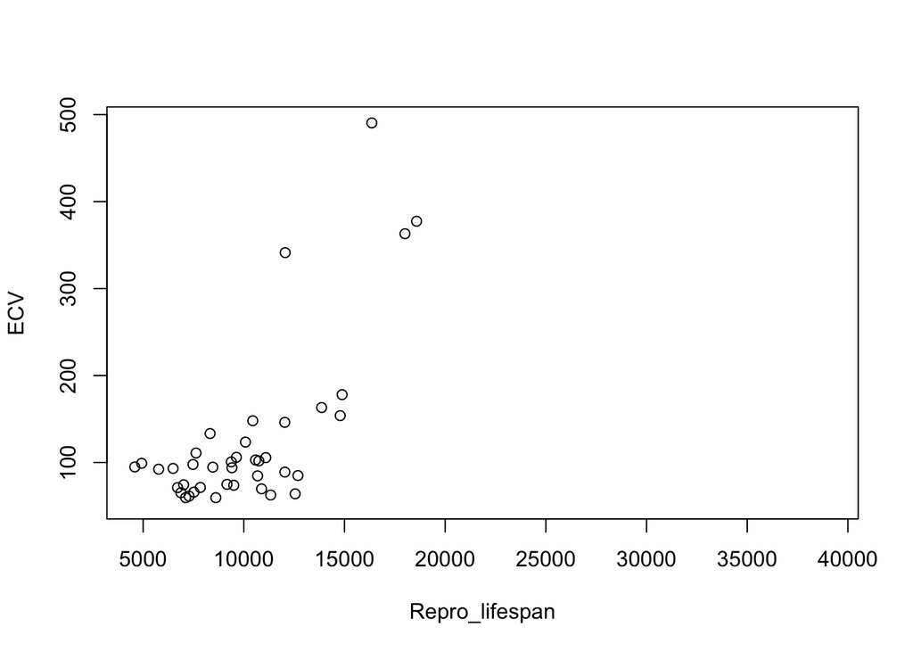

```r
plot(data = Catarrhini, ECV ~ Repro_lifespan)
```

```r
complete_Catarrhini <- Catarrhini[complete.cases(Catarrhini$ECV, Catarrhini$Group_size), ]

(beta1 <- cor(complete_Catarrhini$Group_size, complete_Catarrhini$ECV) * (sd(complete_Catarrhini$ECV)/sd(complete_Catarrhini$Group_size)))
```

```
## [1] 1.146322
```

```r
beta1
```

```
## [1] 1.146322
```

```r
(beta0 <- mean(complete_Catarrhini$ECV) - beta1 * mean(complete_Catarrhini$Group_size))
```

```
## [1] 83.42059
```

```r
beta0
```

```
## [1] 83.42059
```

```r
m <- lm(complete_Catarrhini$ECV ~ complete_Catarrhini$Group_size, data = complete_Catarrhini)
m
```

```
##
## Call:
## lm(formula = complete_Catarrhini$ECV ~ complete_Catarrhini$Group_size,
##     data = complete_Catarrhini)
##
## Coefficients:
##                    (Intercept)  complete_Catarrhini$Group_size
##                         83.421                           1.146
```

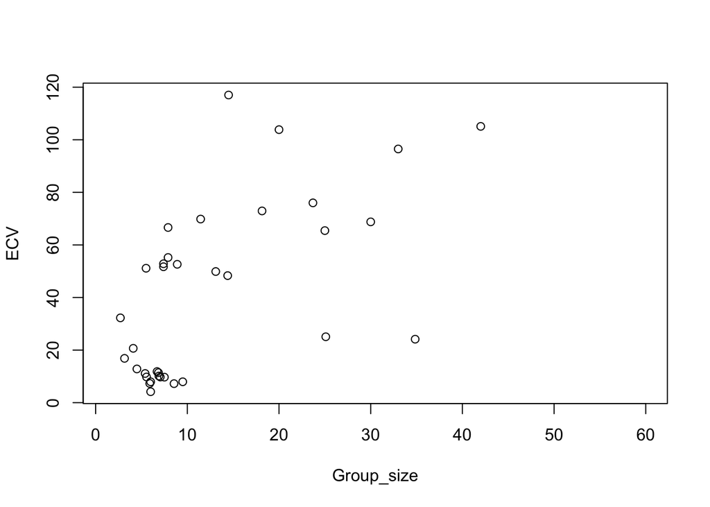

```r
# for platyrrhines

Platyrrhini <- d[d$Taxonomic_group == "Platyrrhini", ]
plot(data = Platyrrhini, ECV ~ Group_size)
```

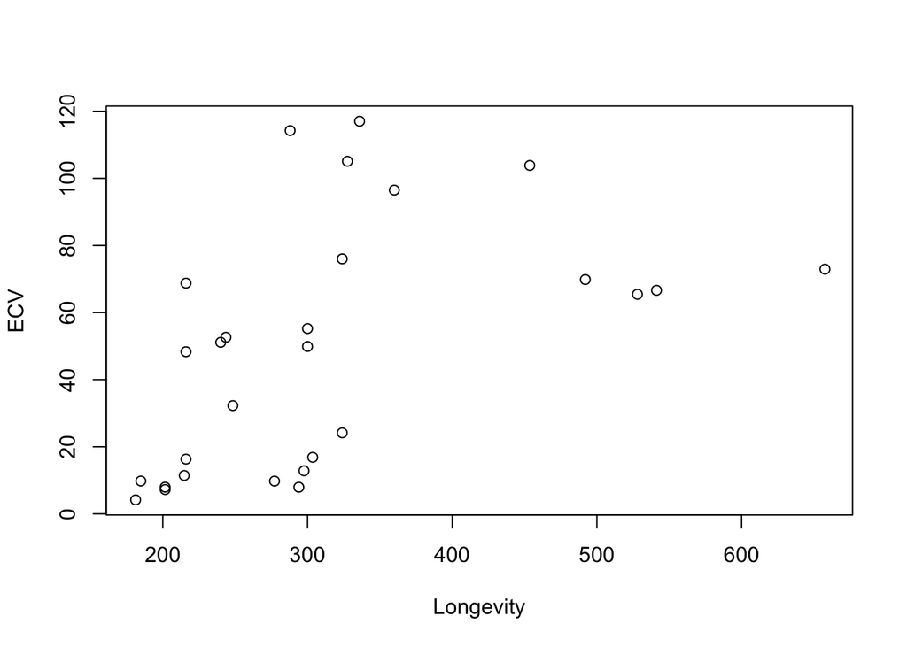

```r
plot(data = Platyrrhini, ECV ~ Longevity)
```

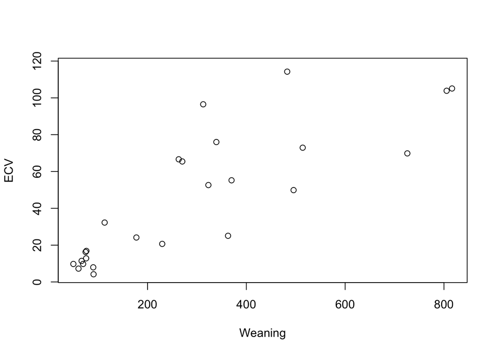

```r
plot(data = Platyrrhini, ECV ~ Weaning)
```

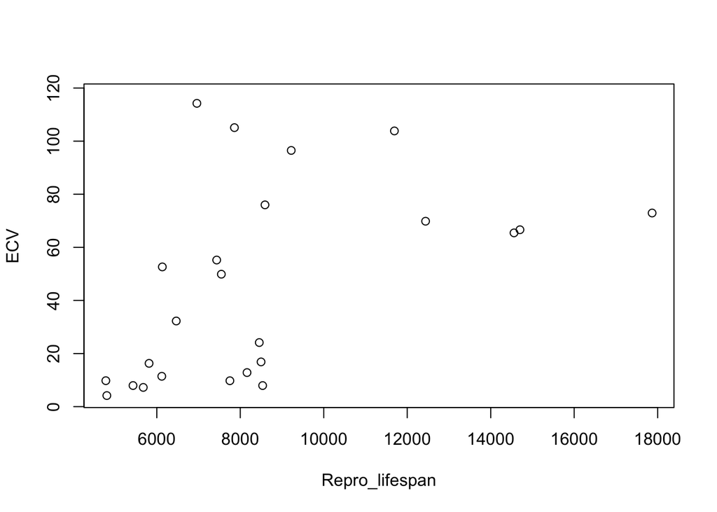

```r
plot(data = Platyrrhini, ECV ~ Repro_lifespan)
```

```r
complete_Platyrrhini <- Platyrrhini[complete.cases(Platyrrhini$ECV, Platyrrhini$Group_size), ]

(beta1 <- cor(complete_Platyrrhini$Group_size, complete_Platyrrhini$ECV) * (sd(complete_Platyrrhini$ECV)/sd(complete_Platyrrhini$Group_size)))
```

```
## [1] 1.965176
```

```r
beta1
```

```
## [1] 1.965176
```

```r
(beta0 <- mean(complete_Platyrrhini$ECV) - beta1 * mean(complete_Platyrrhini$Group_size))
```

```
## [1] 16.18121
```

```r
beta0
```

```
## [1] 16.18121
```

```r
m <- lm(complete_Platyrrhini$ECV ~ complete_Platyrrhini$Group_size, data = complete_Platyrrhini)
m
```

```
##
## Call:
## lm(formula = complete_Platyrrhini$ECV ~ complete_Platyrrhini$Group_size,
##     data = complete_Platyrrhini)
##
## Coefficients:
##                     (Intercept)  complete_Platyrrhini$Group_size
##                          16.181                            1.965
```

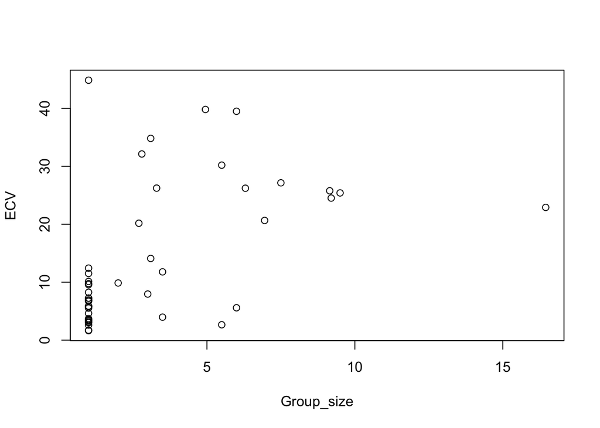

```r
#for strepsirhines

Strepsirhini <- d[d$Taxonomic_group == "Strepsirhini", ]
plot(data = Strepsirhini, ECV ~ Group_size)
```